# Computational Musicology Portfolio Plan

Leander van Boven - 12997080

# The idea

For my project I’m going to do research in the genre of hardstyle music. A lot of people would say that the music within this genre is all alike. However there is a common assumption that each artist distinguishes him- (or her)self with his (or her) unique style and sound. This are most noticable in the tones used in the so called *drop* and as bass-kick.

I’m going to research whether this assumption can be proved with a (computer)model. In particular a classification model that can classify a song with an artist (assumed that this song is of one of the artists used for training the model). Because if such model can be used we can assume that indeed there is something in the songs that are unique for each artist. However if such model is not possible, I’m going to research why this is the case, or what is necessary to create such model.

# The data

To do this research we obviously need some data to work with. For this I’m going to use the songs from the top 5 hardstyle artists together with the songs of my 2 most favorite artists. These artists include:

| Artist | Songs on Spotify |
| --- | --- |
| Noisecontrollers | 199 |
| Headhunterz | 146 |
| Brennan Heart | 100 |
| Showtek | 88 |
| Da Tweekaz | 62 |
| Sub Zero Project | 56 |
| D-Block & S-Te-Fan | 47 |

Together this gives us a corpus of 698 songs where each artist has about 50 songs or more. This should be enough data to build a decent classification model.

# The planning

### Data understanding

Before trying to build a classifier we first need to do some exploration on and understanding of the data. In the first place we need to decide which information we are going to use for the classifier. For example the genre for each artist probably will be similar and thus will not be useful data. Furthermore we have two possible sets of features we can use to train the classifier with:

- *Track Features*, these features are returned by the `get_track_audio_features()` method of the `spotifyr` package. This method is also used to get the track features in the `get_artist_audio_features()` and `get_album_audio_features()` methods. These features are values that say something about the song in a whole, thus we will get 1 feature value per song.
- *Track Analyis*, these features are obtained using the `get_track_audio_analysis()` method fromt the `spotifyr` package. The analysis features are quite a bit more extensive than the track features, thus will probably contain a lot more information about the song. However this means more data, which will take up more disk space, take longer to obtain from Spotify, make the classifiation training take more time and make the model quite a bit more complex (since we now need to add a time dimension to our model).

Because of the reasons described above I’m first going to focus on creating a model created with the *track features*. If I fail to create a good model with these features I’m going to take a look at the *track analysis* features.

The track features include many features including the following numeric features that may be useful:

- Danceability
- Energy
- Key
- Loudness
- Mode
- Speechiness
- Accousticness
- Instrumentalness
- Liveness
- Valence
- Tempo

This is a lot of data in which some features may be very similar for all songs. It is useless to include this data in the trainingsdata for the classifier since it wouldn’t provide good information to distinguish two songs from each other, let alone different artists.

To give a good insight in these features and get a quick overview of which of these may be show some clear differences between the artists, I have combined all songs from all artists into one dataset and plotted each feature:

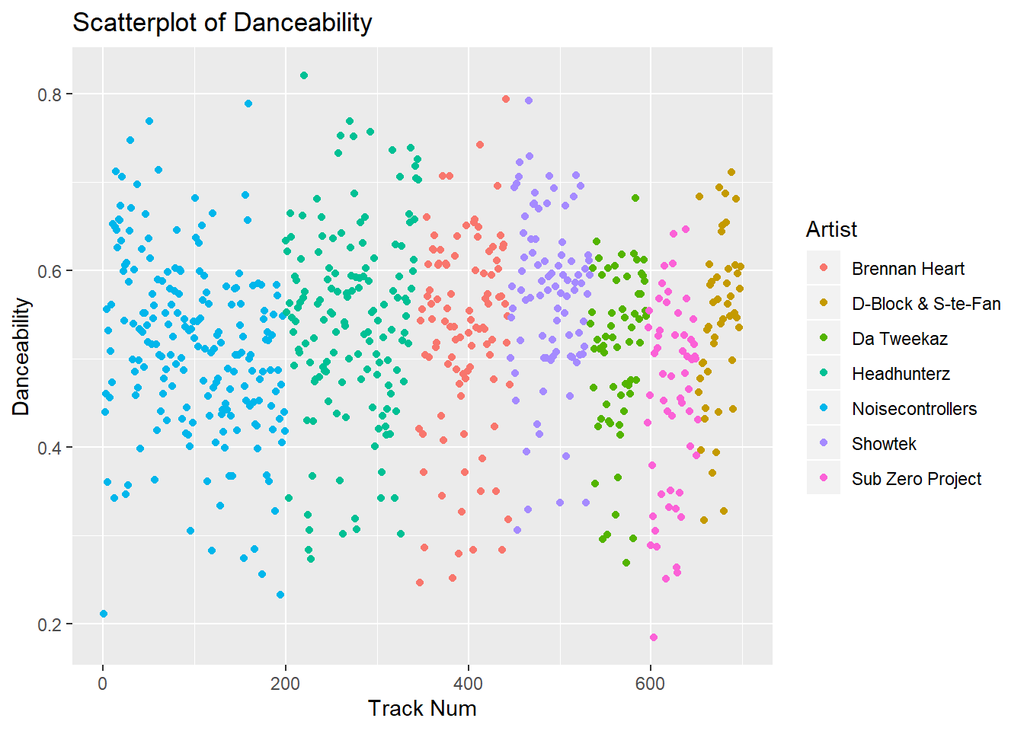

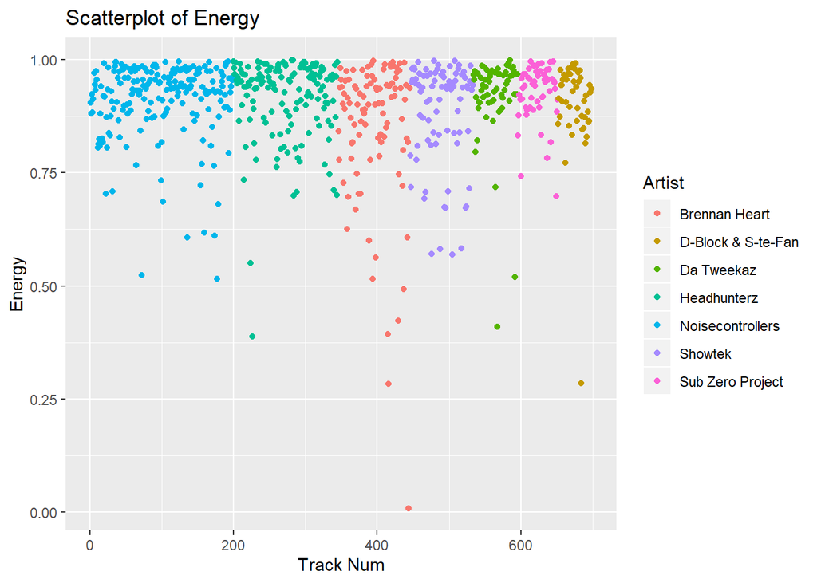

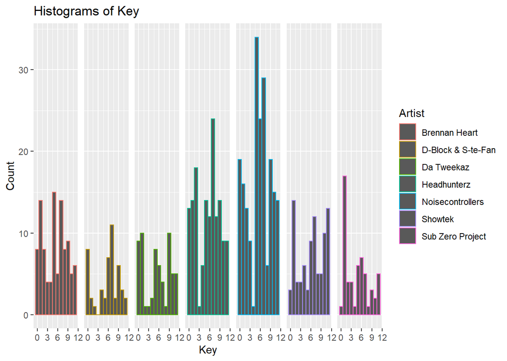

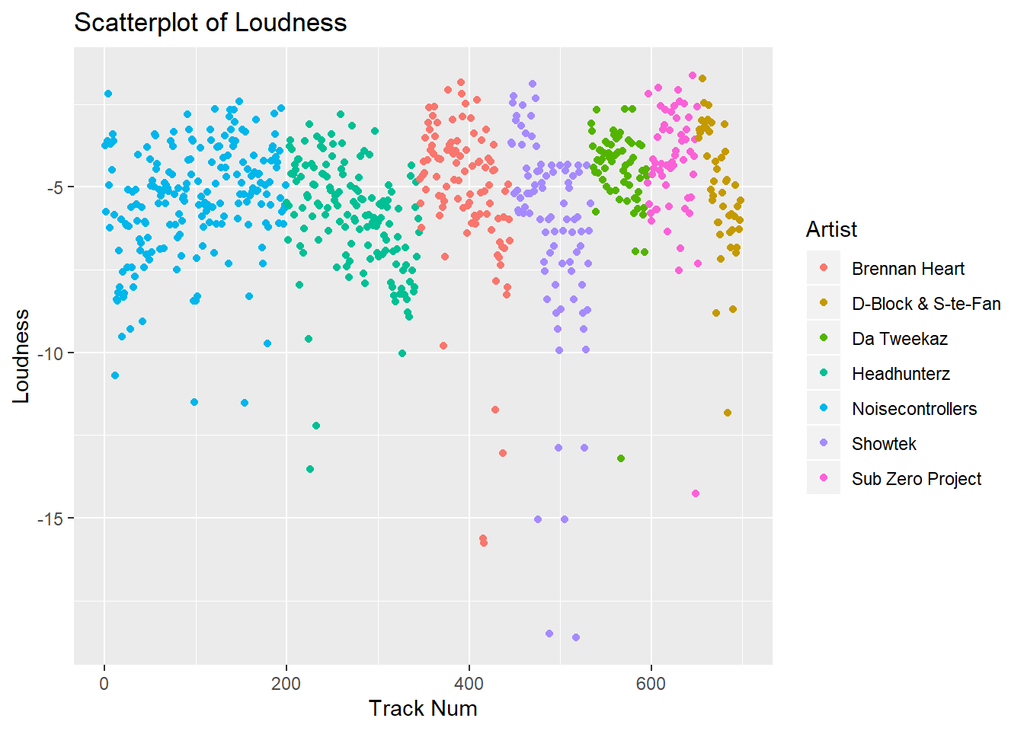

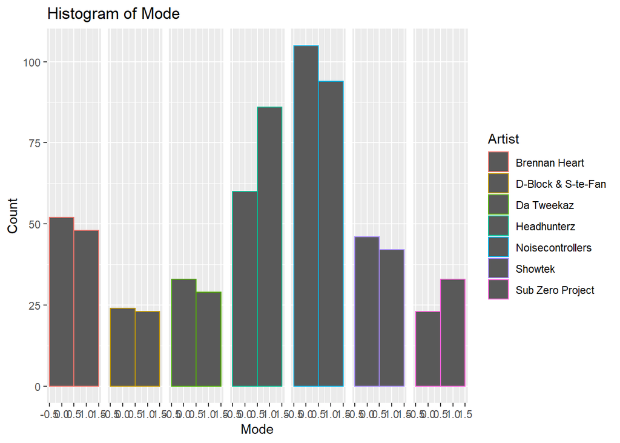

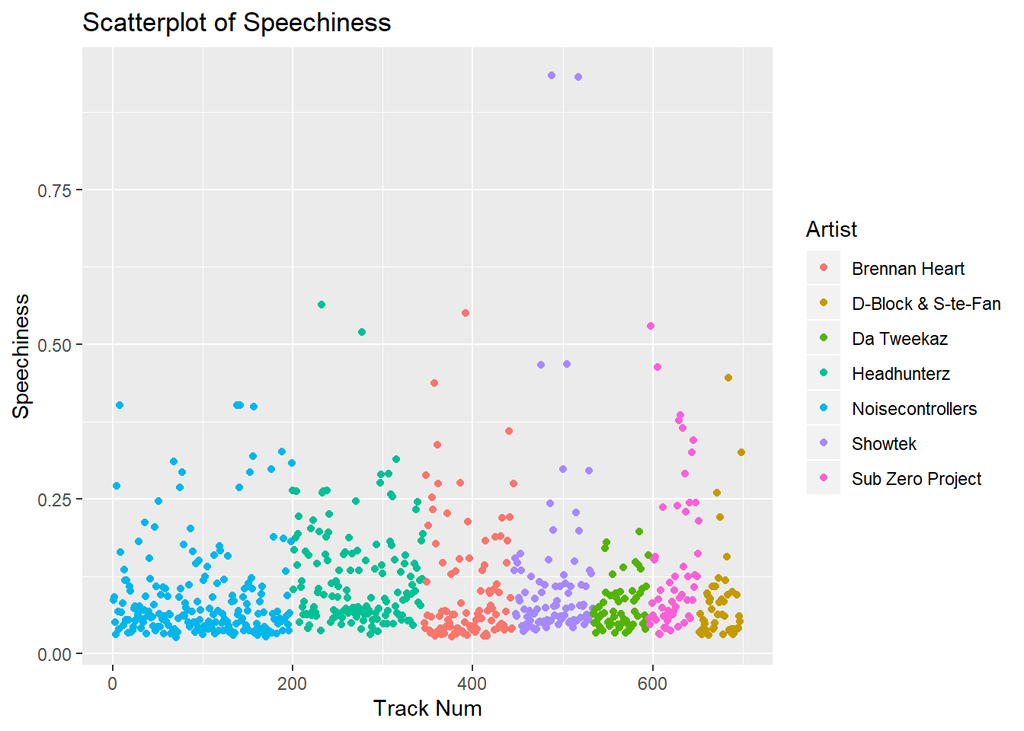

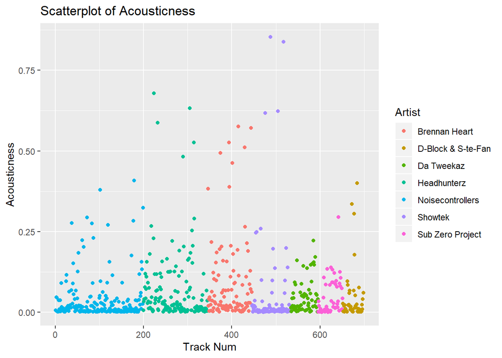

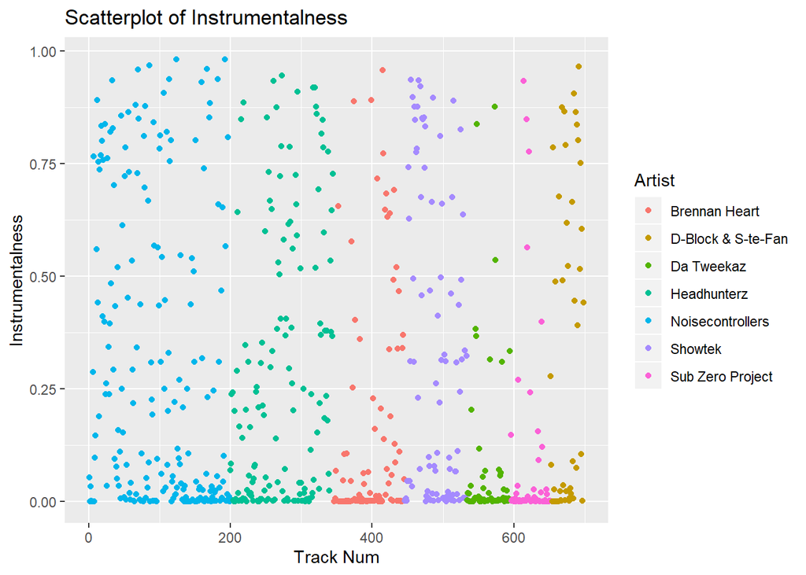

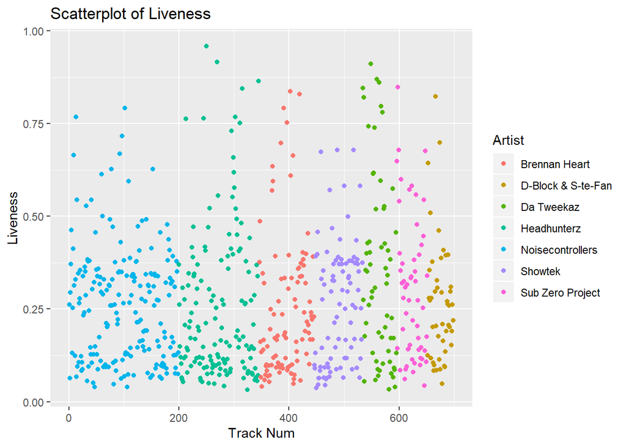

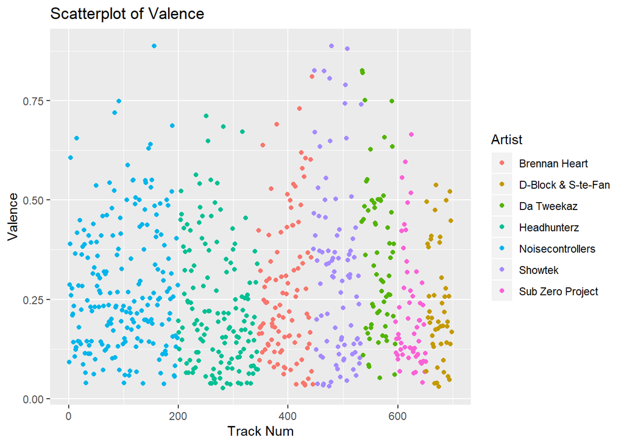

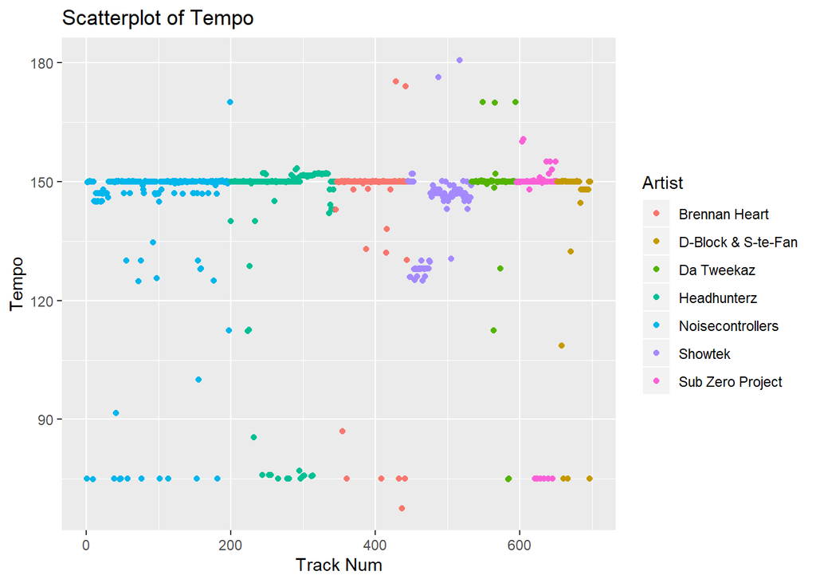

But in for example the *Loudness* plot we can see some clear patterns difference between the artists where the songs of another artist are in the dataset. The *Energy* and *Tempo* plots look promising too.

> All items below are a planning and description of things I’m going to do in the upcoming weeks, these are subject to change as result of feedback and/or new things learned during the course.

### Data Preparation

This is why I’m going to apply a principal component analysis on those possibly information sparse data and use that data to create another model. Principal component analysis means that we reduce the data to a new dataset where each column is an information rich column that captures as much possible variation from the initial data. This data may be even better to use than the features on their own since the PCA data will be more dense in information.

Since we are going to train a classifier we also need to seperate the data into two subsets:

- A trainingset, containing about 80% of the data. This data will be used to train the classifier.
- A testset, containing the remaining 20% of the data. This data will be used to test the classifier.

However, since taking only 20% of the data as validation data, this means we get only 140 songs to validate the classifier. In the best scenario this will mean 20 songs per artist, however since we don’t have an equal amount of songs per artist we will most likely not get 20 songs per artist in the validation data.

For this reason I’m going to perform cross validation on the data with 5 batches. This means that I’m going to shuffle the data and then divide the data into 5 parts (thus each part is 20% of the data). After that I will repeatedly take one part as testset and the other parts as trainingset. This way all data will be once testdata and 4 times trainingsdata, resulting in a model that has seen more data and thus is less overfitted on that data, hopefully giving a model that can classify novel songs better.

### Modeling

As mentioned before I’m going to train multiple models, trained on different subsets of the initial dataset:

- A model trained on all features mentioned in the **Data Understanding** without the *Mode* feature.
- A model trained on (a subset of) the Principal Components.
- (Optionally) A model trained on (a subset of) the `get_track_audio_analysis()` features, if necessary.

Depending on the results of these models I may deduce what is causing them to perform in their way, and build new models that may perform better.

### Evaluation

For each model we can assess it’s performance by the amount of songs it classified correctly. We can use an extensive confusion matrix to compare the amount of correctly classified songs to the amount of incorrect classifications to see which songs are related to each other. After all, if the songs for a certain artist that were incorrectly classified almost always were classified with a certain other artist, those artists must be very similar to each other in terms of the features used for the model.

Optimally we want to create a model that uses only the features returned by the `get_track_audio_features()` method, without diving into the sounds and tune of a song (the data returned by the `get_track_audio_analysis()` method). I’m going to compare the different models with each other and find which model performed best and why. If two artists turn out to be very similar in each model, I may look for the most similar tracks and subjectively compare them by for example listening to them to see whether those tracks are indeed similar to the ear as well.

For the future I hope that some of the artists used to build the model will release new songs, thus allowing me to test the model on novel data to see whether the model is indeed as good as it proved to be on the testdata.